# Fit the model and visualize the effects

## Load packages

```r
library(glmmTMB)
library(tidyverse)
theme_set(theme_bw())
library(cowplot)
library(emmeans)
source('functions.R')
```

```r
library(AfterSl1p)
```

## Load data

```r
coloniz = read.delim('../../data/clean/coloniz_model.txt',
                     sep = '\t',
                     header = TRUE)
```

## Fit the model

The maximal model for this dataset is `zprop_count ~ order*Donor*feature + (Donor + feature | Sample) + (Donor + feature | Cage)`.

Typically, when you fit a random slopes model with more than one slope in the random effect, R will estimate the variance of each slope across the levels of the random effects as well as the correlations between all the slopes within that random effect. However, this variance-covariance matrix is very data-hungry, and when there are not enough samples you can get what is called a “singular” fit. Basically, the variance or covariance estimates are too close to 0.

That is what was happening with our model:

```r
mod_tst <- glmmTMB(zprop_count ~ order*Donor*feature +
                       (Donor + feature | Sample) +
                      (Donor + feature | Cage),
                     data = coloniz)
```

Look at how this model estimates both variances (standard deviations) and correlations:

```r
VarCorr(mod_tst)
```

```
##
## Conditional model:
##  Groups   Name           Std.Dev.      Corr
##  Sample   (Intercept)    3.2764e-01
##           DonorDonorB    4.4467e-01    -0.352
##           featureGene    2.3296e-01    -0.269 -0.777
##           featureMAG     2.3782e-01    -0.372 -0.735  0.981
##           featureSpecies 2.8390e-01    -0.513 -0.553  0.953  0.942
##  Cage     (Intercept)    3.1464e-01
##           DonorDonorB    2.9171e-01    -0.995
##           featureGene    1.7392e-01    -0.563  0.484
##           featureMAG     7.6829e-42    -0.182  0.109  0.853
##           featureSpecies 3.7267e-01    -0.867  0.815  0.855  0.477
##  Residual                2.3433e-01
```

The first step in trying to solve this problem is to fit only the diagonal of the variance-covariance matrix. What that means is that it estimates the variances only and assumes the covariances are 0. I think this is reasonable: we don’t expect any correlation between donor and feature. That model would be `zprop_count ~ order*Donor*feature + (Donor + feature || Sample) + (Donor + feature || Cage)`

Note that in the random effects I have replaced `|` with `||`. That is the syntax for telling `glmmTMB` to only fit the variances, not the covariances.

After I did that, I was still getting a singular fit:

```r
mod_tst <- glmmTMB(zprop_count ~ order*Donor*feature +
                       (Donor + feature || Sample) +
                      (Donor + feature || Cage),
                     data = coloniz)
```

```r
VarCorr(mod_tst)
```

```
##
## Conditional model:
##  Groups   Name           Std.Dev.
##  Sample   (Intercept)    2.4479e-01
##           DonorDonorB    3.0717e-01
##           featureGene    8.4353e-05
##           featureMAG     3.8341e-05
##           featureSpecies 6.6563e-04
##  Cage     (Intercept)    2.8581e-01
##           DonorDonorB    3.7446e-01
##           featureGene    1.6280e-01
##           featureMAG     2.0345e-03
##           featureSpecies 3.4855e-01
##  Residual                2.7389e-01
```

`zprop_count ~ order*Donor*feature + (Donor || Sample) + (Donor + feature || Cage)`.

```r
mod_prz <- glmmTMB(zprop_count ~ order*Donor*feature +
                       (Donor || Sample) +
                      (Donor + feature || Cage),
                     data = coloniz)
```

## Look at model diagnostics

The model diagnostics should be pretty robust to playing with the random effects like that, but let’s check them anyway:

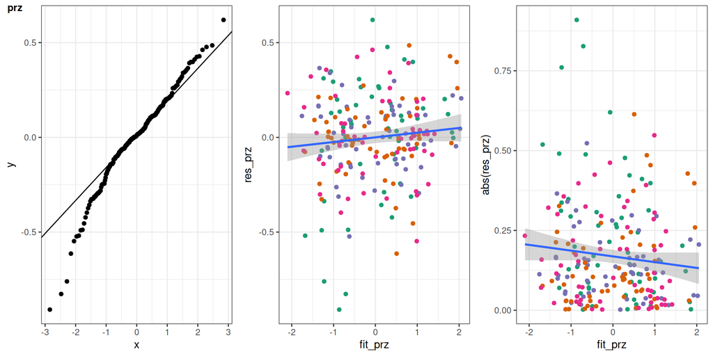

```r
fit_df = (coloniz
          %>% mutate(fit_prz = predict(mod_prz),
                     res_prz = resid(mod_prz)))

mk_plt_row(fit_df, 'prz')
```

It is a little worse than before, but nothing alarming. The zero-slope line fits within the CIs of both of those geom_smooth lines, so I’m calling it good.

## Get the contrasts

### Effect of Donor

Overall effect of donor, averaged across feature types and colonization order:

```r
em_don = emmeans(mod_prz, specs = ~Donor)
```

```
## NOTE: Results may be misleading due to involvement in interactions
```

```r
don_df = data.frame(em_don)
pairs(em_don)
```

```
##  contrast        estimate    SE  df t.ratio p.value
##  DonorA - DonorB     1.52 0.122 192  12.497  <.0001
##
## Results are averaged over the levels of: order, feature
```

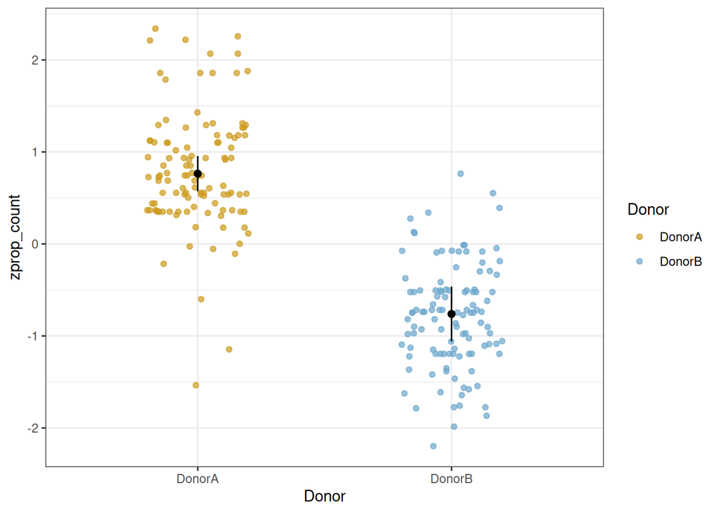

```r
ggplot(don_df, aes(Donor, emmean)) +
  geom_jitter(data = coloniz, aes(y = zprop_count, colour = Donor),
              alpha = 0.7, height = 0, width = 0.2) +
  geom_point(size = 2) +
  geom_linerange(aes(ymin = lower.CL, ymax = upper.CL)) +
  scale_colour_manual(values = c('goldenrod3', 'skyblue3'))
```

Donor A is overall more effective than Donor B at colonizing mice (p < 0.0001).

Effect of donor, within feature type:

```r
em_df = emmeans(mod_prz, specs = ~Donor*feature)
```

```
## NOTE: Results may be misleading due to involvement in interactions
```

```r
pairs(em_df, by = 'feature')
```

```
## feature = Bin:
##  contrast        estimate    SE  df t.ratio p.value
##  DonorA - DonorB     1.31 0.138 192   9.515  <.0001
##
## feature = Gene:
##  contrast        estimate    SE  df t.ratio p.value
##  DonorA - DonorB     1.48 0.138 192  10.717  <.0001
##
## feature = MAG:
##  contrast        estimate    SE  df t.ratio p.value
##  DonorA - DonorB     1.58 0.138 192  11.457  <.0001
##
## feature = Species:
##  contrast        estimate    SE  df t.ratio p.value
##  DonorA - DonorB     1.74 0.138 192  12.620  <.0001
##
## Results are averaged over the levels of: order
```

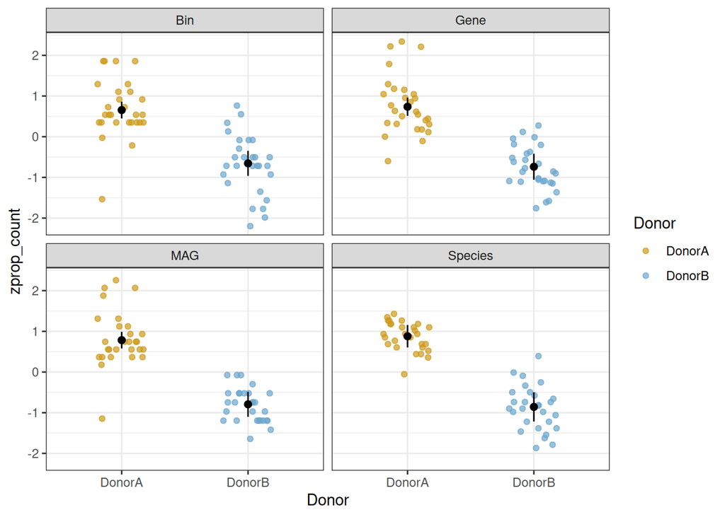

```r
df_df = data.frame(em_df)


ggplot(df_df, aes(Donor, emmean)) +
  geom_jitter(data = coloniz, aes(y = zprop_count, colour = Donor),
              alpha = 0.7, height = 0, width = 0.2) +
  geom_point(size = 2) +
  geom_linerange(aes(ymin = lower.CL, ymax = upper.CL)) +
  scale_colour_manual(values = c('goldenrod3', 'skyblue3')) +
  facet_wrap(~feature)
```

This effect remains strong across all feature types (p < 0.0001 in all cases).

### Effect of order

#### Overall

```r
em_ord = emmeans(mod_prz, specs = ~order)
```

```
## NOTE: Results may be misleading due to involvement in interactions
```

```r
pairs(em_ord)
```

```
##  contrast       estimate    SE  df t.ratio p.value
##  first - mixed     0.409 0.247 192   1.658  0.2240
##  first - second    0.852 0.152 192   5.597  <.0001
##  mixed - second    0.443 0.242 192   1.833  0.1616
##
## Results are averaged over the levels of: Donor, feature
## P value adjustment: tukey method for comparing a family of 3 estimates
```

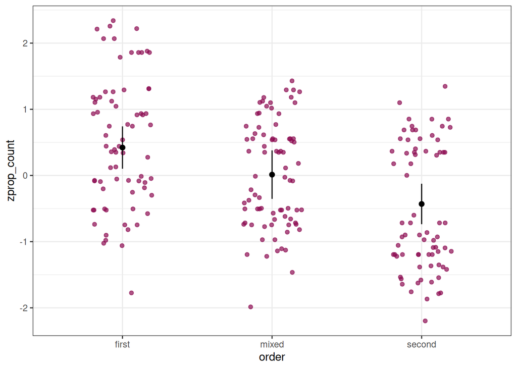

```r
ord_df = data.frame(em_ord)

ggplot(ord_df, aes(order, emmean)) +
  geom_jitter(data = coloniz, aes(y = zprop_count),
              alpha = 0.7, height = 0, width = 0.2,
              colour = 'deeppink4') +
  geom_point(size = 2) +
  geom_linerange(aes(ymin = lower.CL, ymax = upper.CL))
```

Overall, being first is 0.85 s.d. better than being second (p < 0.0001). Although it appears that being second is worse than being in a mixed colony, and being first is better than being in a mixed colony, the signs of these effects is not clear (p = 0.16 and 0.22, respectively).

#### Separated by feature type

```r
em_of = emmeans(mod_prz, specs = ~order*feature)
```

```
## NOTE: Results may be misleading due to involvement in interactions
```

```r
pairs(em_of, by = 'feature')
```

```
## feature = Bin:
##  contrast       estimate    SE  df t.ratio p.value
##  first - mixed   0.56474 0.253 192   2.234  0.0681
##  first - second  0.99637 0.172 192   5.799  <.0001
##  mixed - second  0.43163 0.248 192   1.739  0.1932
##
## feature = Gene:
##  contrast       estimate    SE  df t.ratio p.value
##  first - mixed   0.51572 0.269 192   1.919  0.1361
##  first - second  1.03788 0.172 192   6.041  <.0001
##  mixed - second  0.52216 0.264 192   1.975  0.1211
##
## feature = MAG:
##  contrast       estimate    SE  df t.ratio p.value
##  first - mixed   0.54744 0.253 192   2.165  0.0800
##  first - second  0.97457 0.172 192   5.672  <.0001
##  mixed - second  0.42712 0.248 192   1.721  0.2001
##
## feature = Species:
##  contrast       estimate    SE  df t.ratio p.value
##  first - mixed   0.00833 0.319 192   0.026  0.9996
##  first - second  0.40080 0.172 192   2.333  0.0537
##  mixed - second  0.39247 0.315 192   1.244  0.4288
##
## Results are averaged over the levels of: Donor
## P value adjustment: tukey method for comparing a family of 3 estimates
```

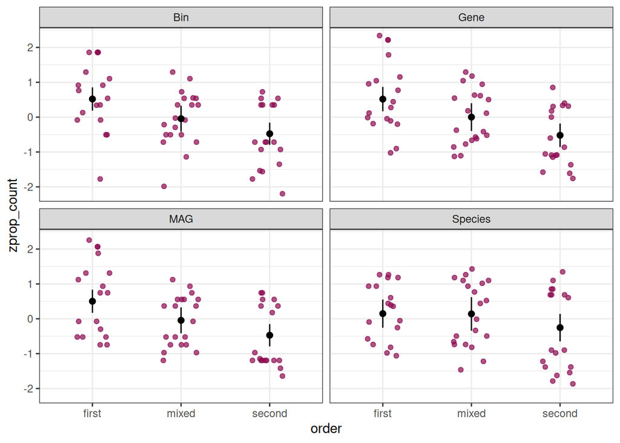

```r
of_df = data.frame(em_of)

ggplot(of_df, aes(order, emmean)) +
  geom_jitter(data = coloniz, aes(y = zprop_count),
              alpha = 0.7, height = 0, width = 0.2,
              colour = 'deeppink4') +
  geom_point(size = 2) +
  geom_linerange(aes(ymin = lower.CL, ymax = upper.CL)) +
  facet_wrap(~feature)
```

The pattern is the same across all feature types; however, the p-value is only significant for three out of four feature types. It is p < 0.0001 for bins, MAGs, and genes, and p = 0.054 for species. No other p-values are significant.

#### Separated by donor

```r
em_od = emmeans(mod_prz, specs = ~order*Donor)
```

```
## NOTE: Results may be misleading due to involvement in interactions
```

```r
pairs(em_od, by = 'Donor')
```

```
## Donor = DonorA:
##  contrast       estimate    SE  df t.ratio p.value
##  first - mixed     0.499 0.228 192   2.188  0.0758
##  first - second    0.803 0.242 192   3.317  0.0031
##  mixed - second    0.304 0.242 192   1.254  0.4231
##
## Donor = DonorB:
##  contrast       estimate    SE  df t.ratio p.value
##  first - mixed     0.319 0.378 192   0.843  0.6767
##  first - second    0.902 0.378 192   2.386  0.0471
##  mixed - second    0.583 0.356 192   1.636  0.2330
##
## Results are averaged over the levels of: feature
## P value adjustment: tukey method for comparing a family of 3 estimates
```

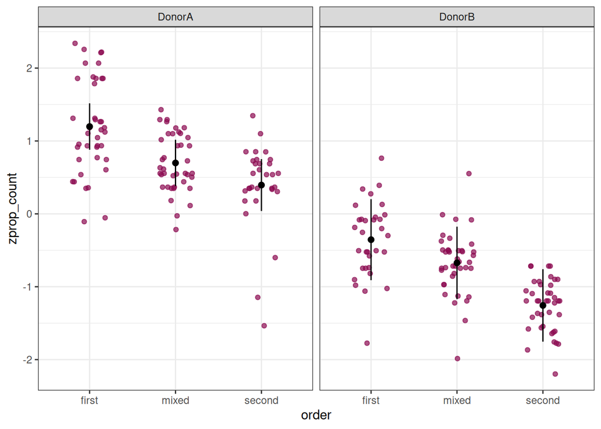

```r
od_df = data.frame(em_od)


ggplot(od_df, aes(order, emmean)) +
  geom_jitter(data = coloniz, aes(y = zprop_count),
              alpha = 0.7, height = 0, width = 0.2,
              colour = 'deeppink4') +
  geom_point(size = 2) +
  geom_linerange(aes(ymin = lower.CL, ymax = upper.CL)) +
  facet_wrap(~Donor)
```

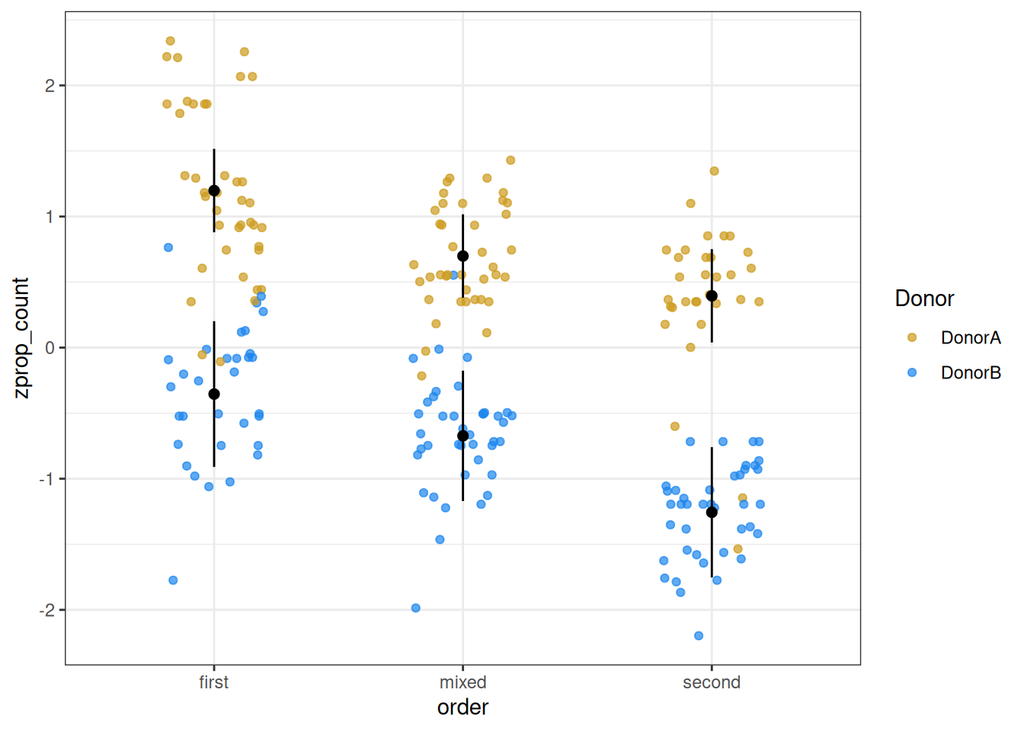

```r
ggplot(od_df, aes(order, emmean)) +
  geom_jitter(data = coloniz, aes(y = zprop_count, colour = Donor),
              alpha = 0.7, height = 0, width = 0.2) +
  geom_point(size = 2) +
  geom_linerange(aes(ymin = lower.CL, ymax = upper.CL)) +
  scale_colour_manual(values = c('goldenrod3', 'dodgerblue2'))
```

Again, the pattern persists, but it is noisier.

#### Separated by both feature type and donor

```r
em = emmeans(mod_prz, specs = ~ order*Donor*feature)
pairs(em, by = c('feature', 'Donor'))
```

```
## feature = Bin, Donor = DonorA:
##  contrast       estimate    SE  df t.ratio p.value
##  first - mixed    0.7541 0.244 192   3.088  0.0065
##  first - second   1.0463 0.259 192   4.040  0.0002
##  mixed - second   0.2922 0.259 192   1.128  0.4979
##
## feature = Gene, Donor = DonorA:
##  contrast       estimate    SE  df t.ratio p.value
##  first - mixed    0.5765 0.265 192   2.175  0.0780
##  first - second   1.0582 0.281 192   3.764  0.0006
##  mixed - second   0.4817 0.281 192   1.713  0.2028
##
## feature = MAG, Donor = DonorA:
##  contrast       estimate    SE  df t.ratio p.value
##  first - mixed    0.8317 0.244 192   3.404  0.0023
##  first - second   1.1483 0.259 192   4.431  <.0001
##  mixed - second   0.3166 0.259 192   1.222  0.4418
##
## feature = Species, Donor = DonorA:
##  contrast       estimate    SE  df t.ratio p.value
##  first - mixed   -0.1648 0.329 192  -0.501  0.8709
##  first - second  -0.0412 0.349 192  -0.118  0.9923
##  mixed - second   0.1236 0.349 192   0.354  0.9332
##
## feature = Bin, Donor = DonorB:
##  contrast       estimate    SE  df t.ratio p.value
##  first - mixed    0.3754 0.389 192   0.965  0.6000
##  first - second   0.9465 0.389 192   2.432  0.0419
##  mixed - second   0.5711 0.367 192   1.557  0.2671
##
## feature = Gene, Donor = DonorB:
##  contrast       estimate    SE  df t.ratio p.value
##  first - mixed    0.4549 0.404 192   1.125  0.4996
##  first - second   1.0176 0.404 192   2.518  0.0337
##  mixed - second   0.5627 0.381 192   1.477  0.3045
##
## feature = MAG, Donor = DonorB:
##  contrast       estimate    SE  df t.ratio p.value
##  first - mixed    0.2632 0.389 192   0.676  0.7776
##  first - second   0.8009 0.389 192   2.058  0.1015
##  mixed - second   0.5376 0.367 192   1.465  0.3100
##
## feature = Species, Donor = DonorB:
##  contrast       estimate    SE  df t.ratio p.value
##  first - mixed    0.1815 0.454 192   0.400  0.9157
##  first - second   0.8428 0.454 192   1.857  0.1543
##  mixed - second   0.6613 0.428 192   1.545  0.2723
##
## P value adjustment: tukey method for comparing a family of 3 estimates
```

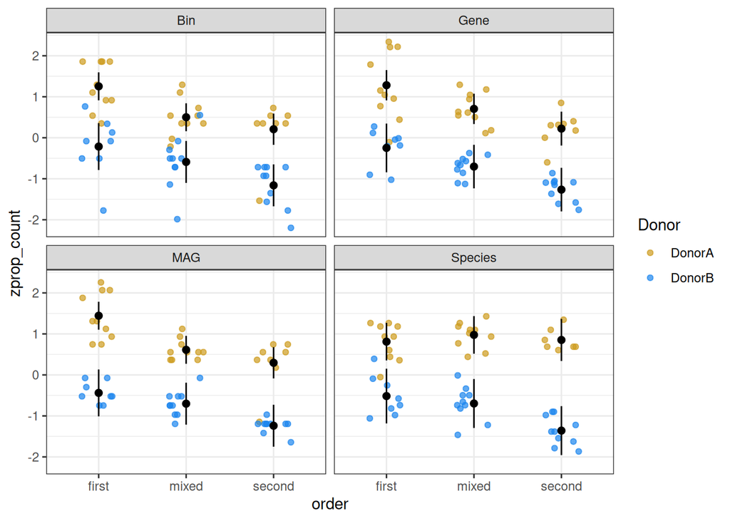

```r
all_df = data.frame(em)

ggplot(all_df, aes(order, emmean)) +
  geom_jitter(data = coloniz, aes(y = zprop_count, colour = Donor),
              alpha = 0.7, height = 0, width = 0.2) +
  geom_point(size = 2) +
  geom_linerange(aes(ymin = lower.CL, ymax = upper.CL)) +
  facet_wrap(~feature) +
  scale_colour_manual(values = c('goldenrod3', 'dodgerblue2'))
```

Again the pattern persists, although not all p-values between first and second are <0.05. I’m not convinced this is the best way to show it though. Let’s try a coefficient plot:

```r
pdf = (em
       %>% pairs(by = c('feature', 'Donor'))
       %>% data.frame()
       %>% separate_wider_delim(contrast, ' - ', names = c('bottom','top'))
       %>% mutate(bottom = factor(bottom, levels = c('first', 'second', 'mixed')),
                  top = factor(top, levels = levels(bottom)),
                  contrast = paste(top, bottom, sep = '-'),
                  contrast = order_levs(factor(contrast), top, bottom),
                  estimate = -1 * estimate))
pdf
```

```
## # A tibble: 24 × 10
##    bottom top    feature Donor  estimate    SE    df t.ratio  p.value contrast
##    <fct>  <fct>  <fct>   <fct>     <dbl> <dbl> <dbl>   <dbl>    <dbl> <fct>
##  1 first  mixed  Bin     DonorA   -0.754 0.244   192   3.09  0.00651  mixed-fir…
##  2 first  second Bin     DonorA   -1.05  0.259   192   4.04  0.000227 second-fi…
##  3 mixed  second Bin     DonorA   -0.292 0.259   192   1.13  0.498    second-mi…
##  4 first  mixed  Bin     DonorB   -0.375 0.389   192   0.965 0.600    mixed-fir…
##  5 first  second Bin     DonorB   -0.946 0.389   192   2.43  0.0419   second-fi…
##  6 mixed  second Bin     DonorB   -0.571 0.367   192   1.56  0.267    second-mi…
##  7 first  mixed  Gene    DonorA   -0.577 0.265   192   2.18  0.0780   mixed-fir…
##  8 first  second Gene    DonorA   -1.06  0.281   192   3.76  0.000647 second-fi…
##  9 mixed  second Gene    DonorA   -0.482 0.281   192   1.71  0.203    second-mi…
## 10 first  mixed  Gene    DonorB   -0.455 0.404   192   1.13  0.500    mixed-fir…
## # ℹ 14 more rows
```

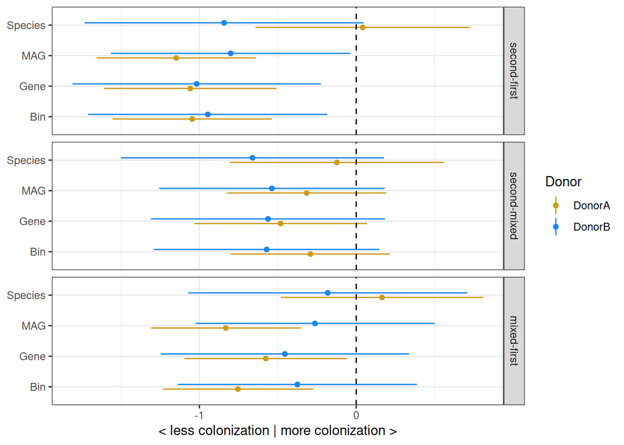

```r
ggplot(pdf, aes(feature, estimate, colour = Donor)) +
  geom_point(position = position_dodge(width = 0.3)) +
  geom_linerange(aes(ymin = estimate - (1.96*SE),
                     ymax = estimate + (1.96*SE)),
                 position = position_dodge(width = 0.3)) +
  geom_hline(yintercept = 0, linetype = 2) +
  coord_flip() +
  ylab('< less colonization | more colonization >') +
  facet_wrap(contrast~., ncol = 1, strip.position = 'right') +
  scale_colour_manual(values = c('goldenrod3', 'dodgerblue2')) +
  theme(axis.title.y = element_blank())
```

What we see here is that there is more colonization from first-microbiome bugs than from second-microbiome bugs, and that this effect is slightly stronger in donor A than donor B. This is true across all feature types except, somehow, disappears in donor A with species.

Finally, there is a pattern of less colonization from second-microbiome bugs than from mixed-microbiome bugs but, again, this effect is smaller and the pattern is noisier

## Assorted other coeffecient plots we may or may not want

Effect of donor, split up by feature type:

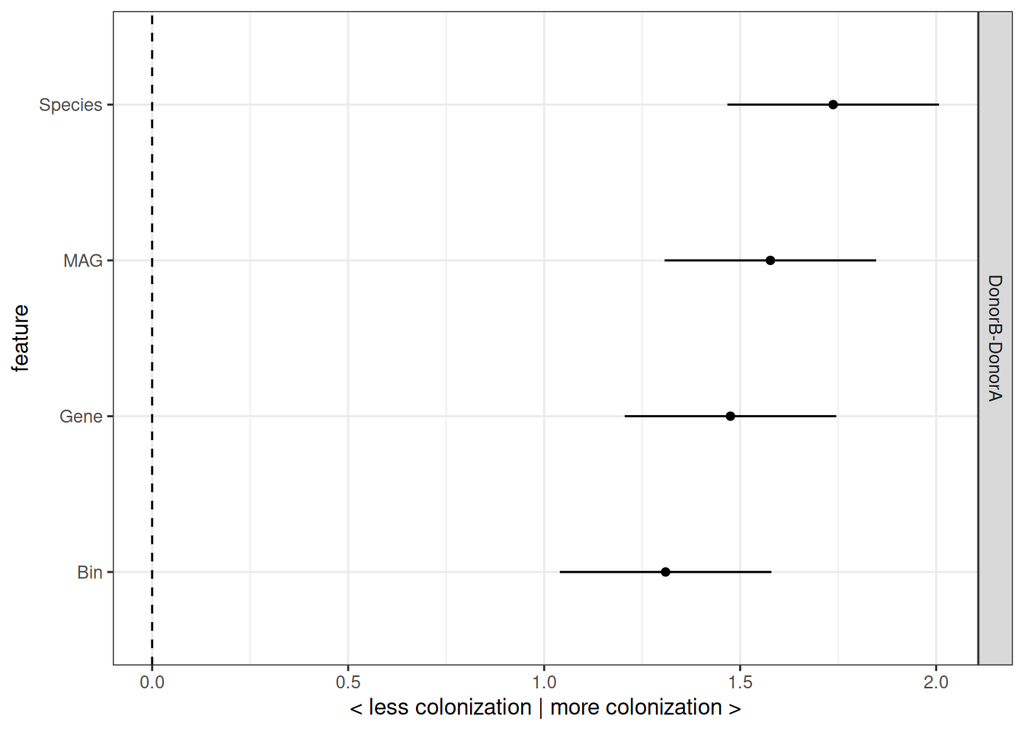

```r
con_df = data.frame(pairs(em_df, by = 'feature'))
con_df = (con_df
       %>% separate_wider_delim(contrast, ' - ', names = c('bottom','top'))
       %>% mutate(bottom = factor(bottom, levels = c('DonorB', 'DonorA')),
                  top = factor(top, levels = levels(bottom)),
                  contrast = paste(top, bottom, sep = '-'),
                  contrast = order_levs(factor(contrast), top, bottom),
                  Donor = NA)
       %>% select(bottom, top, feature, Donor, everything()))

ggplot(con_df, aes(feature, estimate)) +
  geom_point() +
  geom_hline(yintercept = 0, linetype = 2) +
  geom_linerange(aes(ymin = estimate - (1.96*SE),
                     ymax = estimate + (1.96*SE))) +
  facet_wrap(~contrast, strip.position = 'right') +
  ylab('< less colonization | more colonization >') +
  coord_flip()
```

All the coefficients together

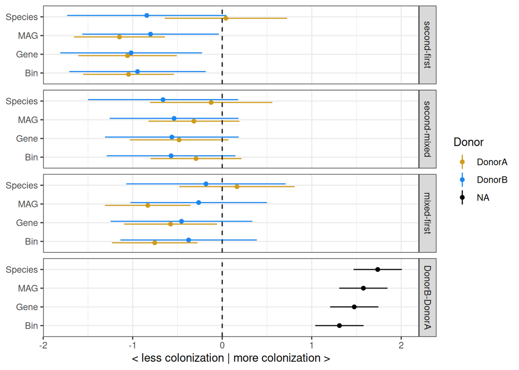

```r
tst = rbind(pdf, con_df)

ggplot(tst, aes(feature, estimate, colour = Donor)) +
  geom_point(position = position_dodge(width = 0.3)) +
  geom_linerange(aes(ymin = estimate - (1.96*SE),
                     ymax = estimate + (1.96*SE)),
                 position = position_dodge(width = 0.3)) +
  geom_hline(yintercept = 0, linetype = 2) +
  coord_flip() +
  ylab('< less colonization | more colonization >') +
  facet_wrap(contrast~., ncol = 1, strip.position = 'right') +
  scale_colour_manual(values = c('goldenrod3', 'dodgerblue2'),
                      na.value = 'black') +
  theme(axis.title.y = element_blank())
```

Facet by feature instead of by contrast:

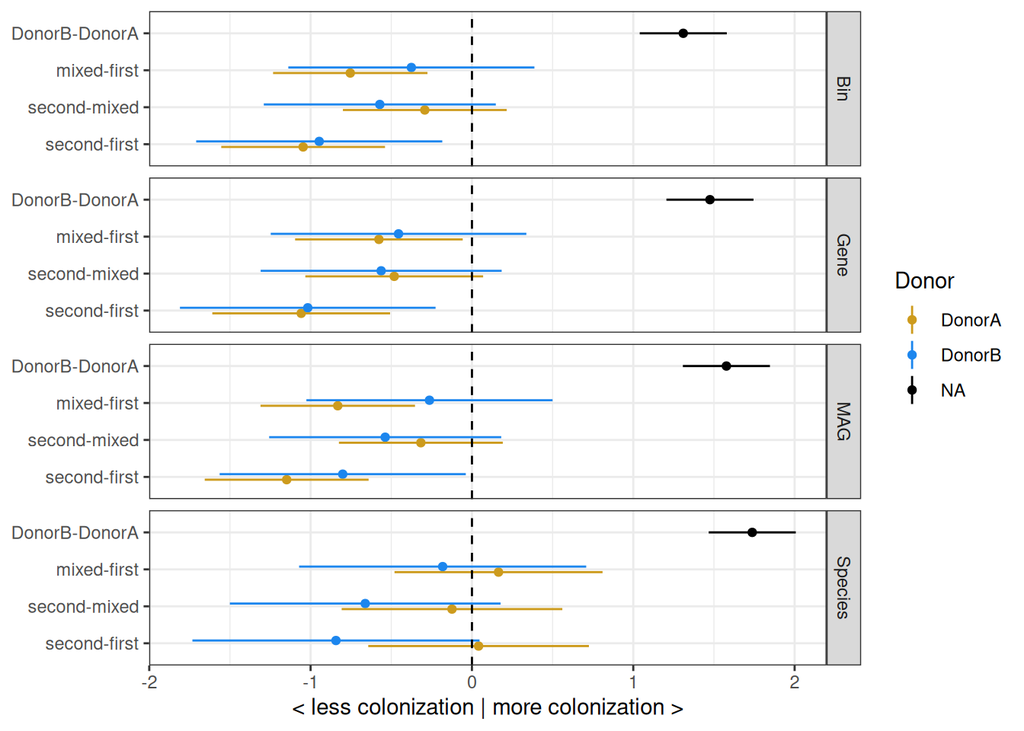

```r
ggplot(tst, aes(contrast, estimate, colour = Donor)) +
  geom_point(position = position_dodge(width = 0.3)) +
  geom_linerange(aes(ymin = estimate - (1.96*SE),
                     ymax = estimate + (1.96*SE)),
                 position = position_dodge(width = 0.3)) +
  geom_hline(yintercept = 0, linetype = 2) +
  coord_flip() +
  ylab('< less colonization | more colonization >') +
  facet_wrap(feature~., ncol = 1, strip.position = 'right') +
  scale_colour_manual(values = c('goldenrod3', 'dodgerblue2'),
                      na.value = 'black') +
  theme(axis.title.y = element_blank())
```

This seems pretty obviously worse, but I just included it as an example of options.